# Processing open text responses for locations

Ali Colmenares

2020-11-30

### Notes

Purpose: This script assesses the RISK ‘other locations’ responses and recommends additional location types for RISK 2

Inputs:

- locations_abby REAL.csv

### Setup

Paths

```r
path_other_locations <- "./raw_data/locations"
```

Packages and Source

```r
library(tidyverse)
library(janitor)
library(tidytext)
library(wordcloud)
library(gt)
```

### Import and wrangle

```r
other_location_names <- read_csv("./raw_data/locations/locations_abby REAL.csv") %>% #for now, just using abby's codes
  filter(!is.na(description)) %>%
  mutate(description = tolower(description)) %>%
  pull(description)
```

#### Describe ‘other’ places

Tokenized Phrases

```r
text_df <- tibble(line = 1:length(other_location_names),
                  text = other_location_names) %>%
  unnest_tokens(word, text) %>%
  rename(text = word) %>%
  anti_join(stop_words, by = c("text" = "word")) %>%
  count(text, sort = TRUE)


text_df %>%
  filter(n > 4) %>%
  gt()
```

| text | n |
| --- | --- |
| library | 58 |
| hotel | 40 |
| airport | 38 |
| bus | 28 |
| church | 24 |
| stop | 21 |
| store | 20 |
| center | 18 |
| school | 18 |
| house | 16 |
| home | 15 |
| station | 15 |
| mall | 14 |
| venue | 14 |
| club | 12 |
| movies | 12 |
| salon | 12 |
| vacation | 12 |
| concert | 10 |
| golf | 10 |
| shop | 10 |
| transfer | 10 |
| union | 10 |
| car | 9 |
| gas | 9 |
| kids | 9 |
| movie | 9 |
| music | 9 |
| office | 9 |
| park | 9 |
| theatre | 9 |
| hunting | 8 |
| vet | 8 |
| pantry | 7 |
| theater | 7 |
| auto | 6 |
| friend | 6 |
| market | 6 |
| parking | 6 |
| son's | 6 |
| terrace | 6 |
| tour | 6 |
| air | 5 |
| bank | 5 |
| beach | 5 |
| bnb | 5 |
| boyfriend's | 5 |
| cabin | 5 |
| casino | 5 |
| community | 5 |
| conference | 5 |
| courthouse | 5 |
| dog | 5 |
| family | 5 |
| museum | 5 |
| nail | 5 |
| thrift | 5 |

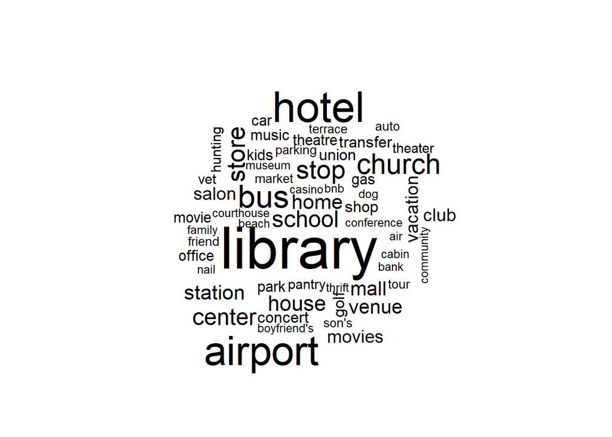

```r
wordcloud(text_df$text, text_df$n,
          min.freq = 5)
```

The ten most commonly used tokens are ‘library’, ‘hotel’, ‘airport’, ‘bus’,‘church’, ‘stop’, ‘store’, ‘center’, ‘school’, and ‘house’.

Complete Phrases

```r
text_df <- tibble(line = 1:length(other_location_names),
                  text = other_location_names) %>%
  anti_join(stop_words, by = c("text" = "word")) %>%
  count(text, sort = TRUE)


text_df %>%
  filter(n > 4) %>%
  gt()
```

| text | n |
| --- | --- |
| library | 55 |
| hotel | 36 |
| airport | 35 |
| church | 21 |
| bus stop | 19 |
| movies | 12 |
| mall | 10 |
| golf course | 9 |
| gas station | 8 |
| concert venue | 7 |
| movie theatre | 7 |
| salon | 7 |
| tour | 6 |
| air bnb | 5 |
| bank | 5 |
| casino | 5 |
| kids school | 5 |
| museum | 5 |
| theater | 5 |
| vacation | 5 |

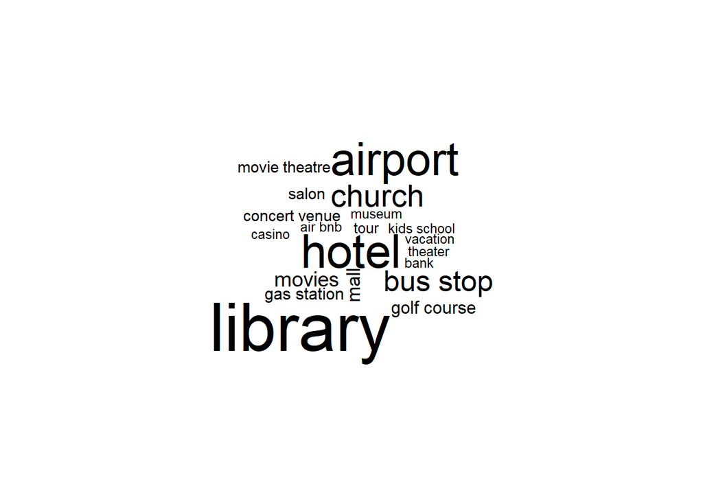

```r
wordcloud(text_df$text, text_df$n,
          min.freq = 5)
```

Assess Risk2 measure

```r
new_text_df <- filter(text_df, !text %in% c("library", "hotel", "church", "bus stop", "bus station", "motel", "hospital", "p.o", "transfer point", "bank", "community center", "west transfer point"))

new_text_df %>%
  filter(n > 4) %>%
  gt()
```

| text | n |
| --- | --- |
| airport | 35 |
| movies | 12 |
| mall | 10 |
| golf course | 9 |
| gas station | 8 |
| concert venue | 7 |
| movie theatre | 7 |
| salon | 7 |
| tour | 6 |
| air bnb | 5 |
| casino | 5 |
| kids school | 5 |
| museum | 5 |
| theater | 5 |
| vacation | 5 |

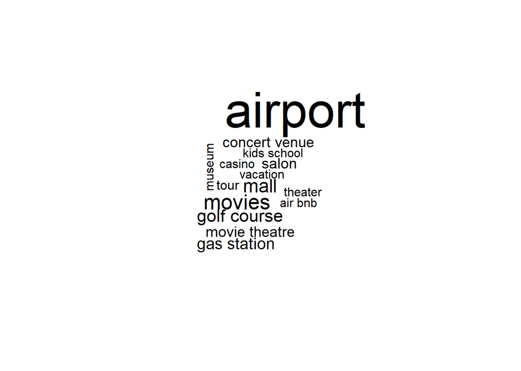

```r
wordcloud( new_text_df$text, new_text_df$n,
          min.freq = 5)
```

Recommended actions:

- Create an ‘Entertainment Venue (Movie Theater, Concert)’ option
- Create a ‘Malls’
- Consider adding ‘Airport’ to the examples for transportation point.
- Consider creating a ‘Salon/Barbershop’ category
- Consider creating a ‘Gas station’ category
- Consider creating a ‘Recreational activity (Golf, Swimming, Camping, Etc.)’ option
- Consider creating a ‘Child’s School/Daycare’ option